# Sesión técnica para el COAATIEA

## Recursos telemáticos para georreferenciación

Miguel Fernández Moreno Técnico del [Laboratorio de Geomática](http://iig.ua.es/es/geomatica/) del [Instituto Interuniversitario de Geografía](http://iig.ua.es/) / [Proyecto Ramón Llull](http://www.arsmagna.es) / [@P_RamonLlull](https://twitter.com/P_RamonLlull)

### Formatos para presentación en Catastro

- Fichero GML: para agregaciones, segregaciones, divisiones y deslindes > Se basa en el esquema [**Cadastral Parcel**](https://inspire-forum.jrc.ec.europa.eu/pg/pages/view/1806/cadastral-parcels) de INSPIRE
- Fichero DXF: para obras nuevas y divisiones horizontales. > El formato GML para edificios basado en el esquema [**Building**](http://inspire.ec.europa.eu/documents/Data_Specifications/INSPIRE_DataSpecification_BU_v3.0rc3.pdf) de INSPIRE, no se va generará hasta que el formato no esté plenamente operativo en Catastro.

### Aplicación Ramón Llull. Casos de uso.

- Alteraciones catastrales:
  - Agregación: agrupación de 2 o más fincas.
  - Segregación: división con resultado de una nueva finca segregada y un resto de finca matriz que conserva la referencia catastral original.
  - División para reparcelación: división con resultado de dos o más fincas nuevas y desaparición de la referencia catastral original.
- Deslindes: resuelve la subsanación de discrepancias.
- Obra nueva: permite resolver el procedimiento de inscripción de edificaciones en régimen de propiedad horizontal, y engloba tanto la vivienda nueva como la legalización de vivienda existente…

#### Agregación

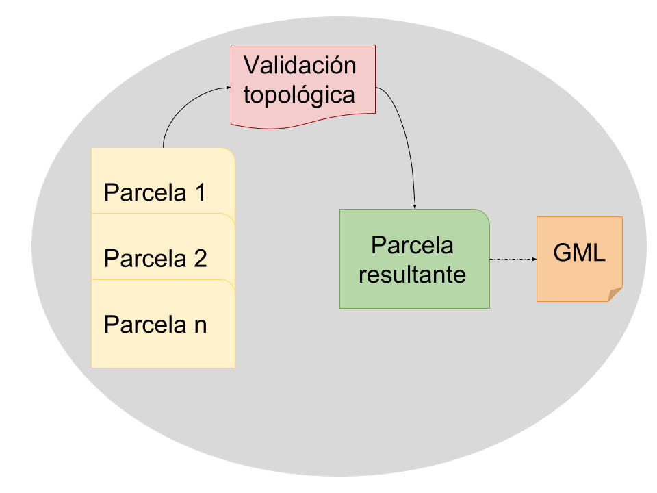

#### Segregación

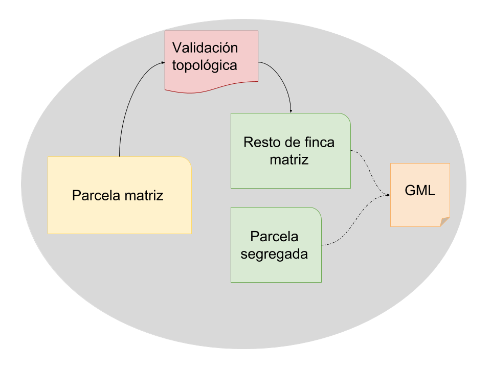

#### División

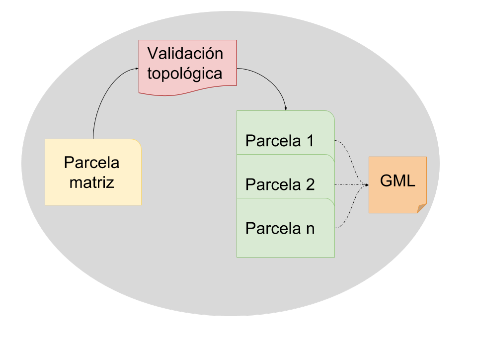

#### Deslinde

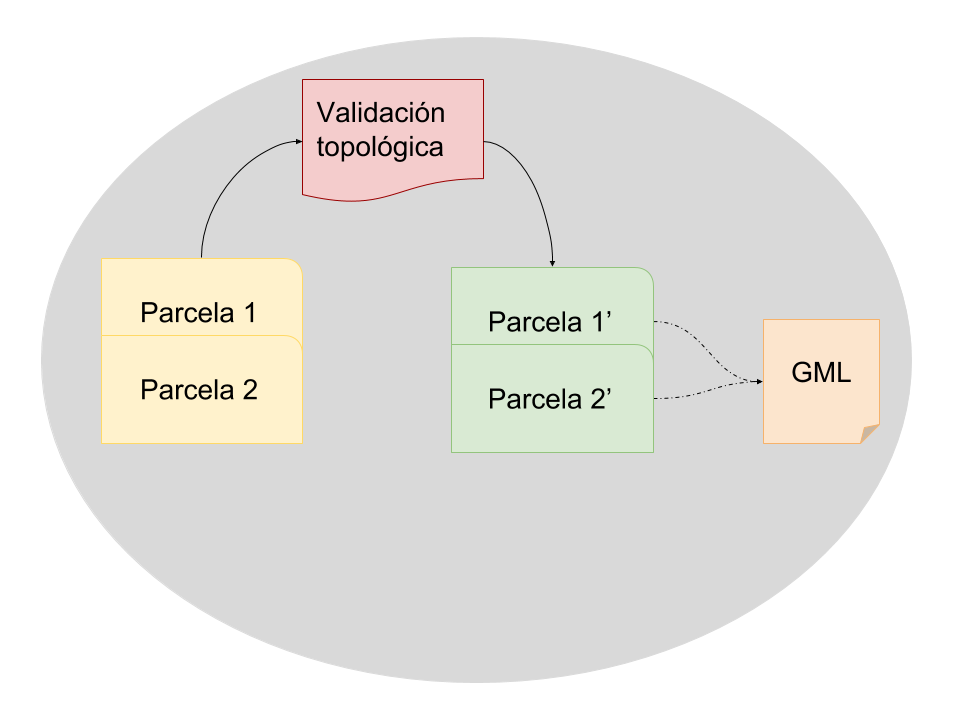

#### Obra nueva

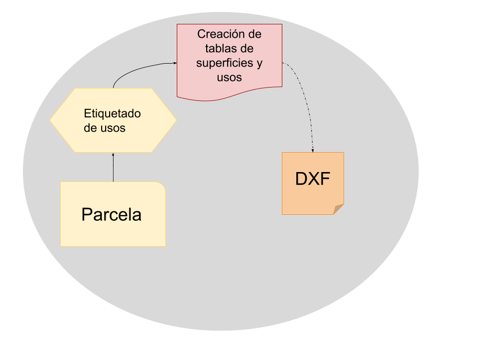

#### Cómo tramitar alteraciones catastrales en 5 pasos

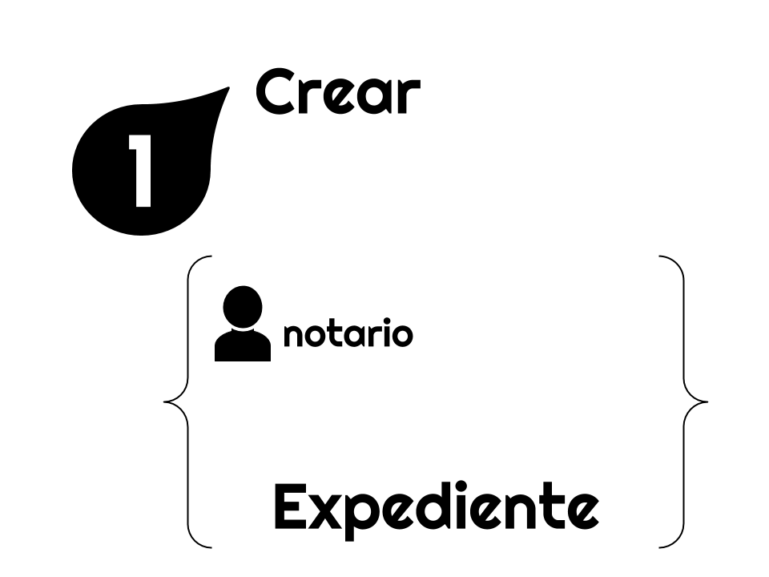

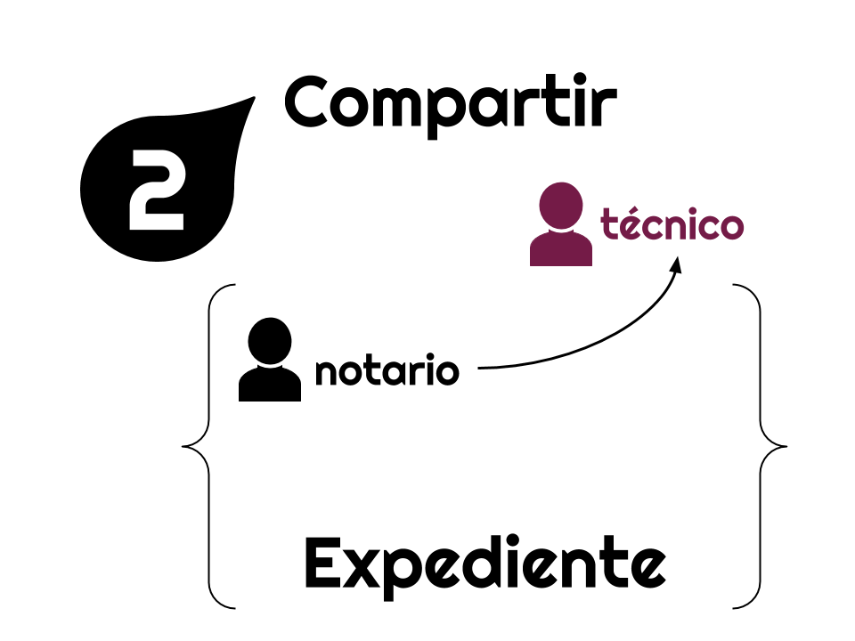

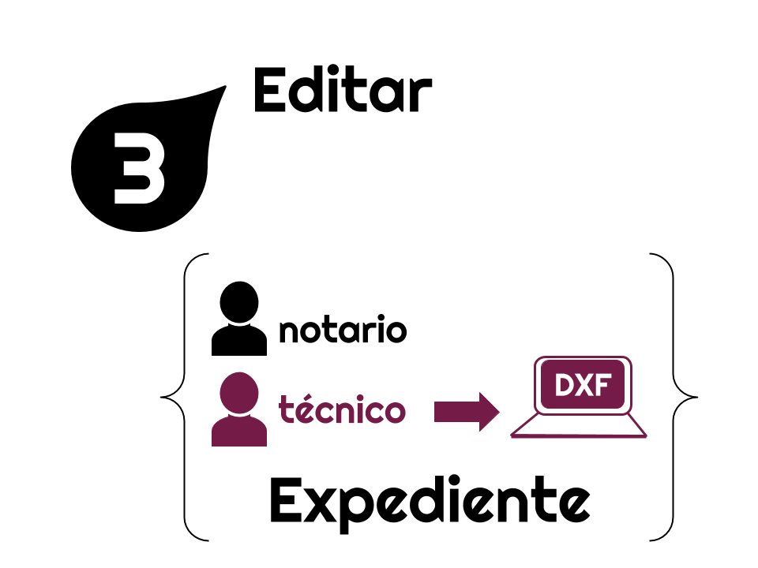

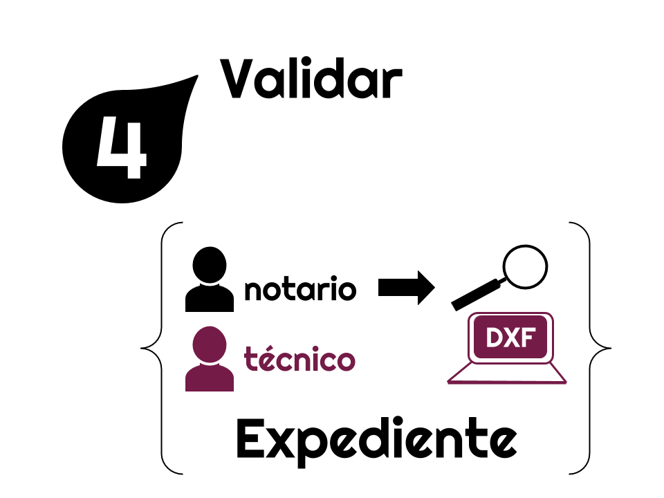

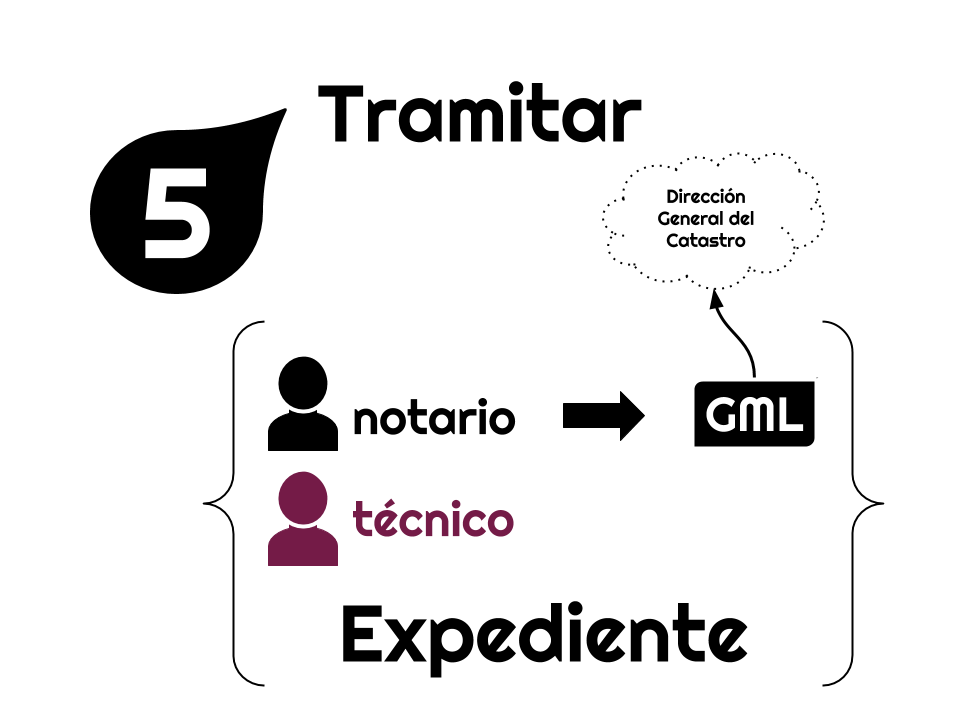

#### Veamos un ejemplo para una alteración catastral

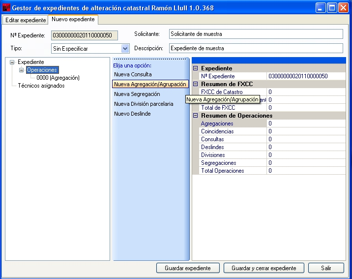

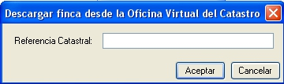

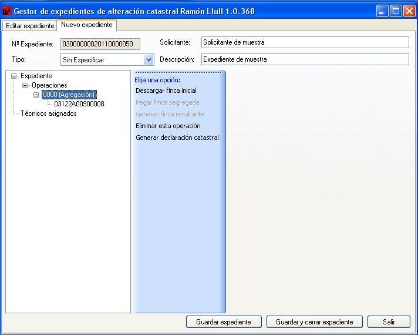

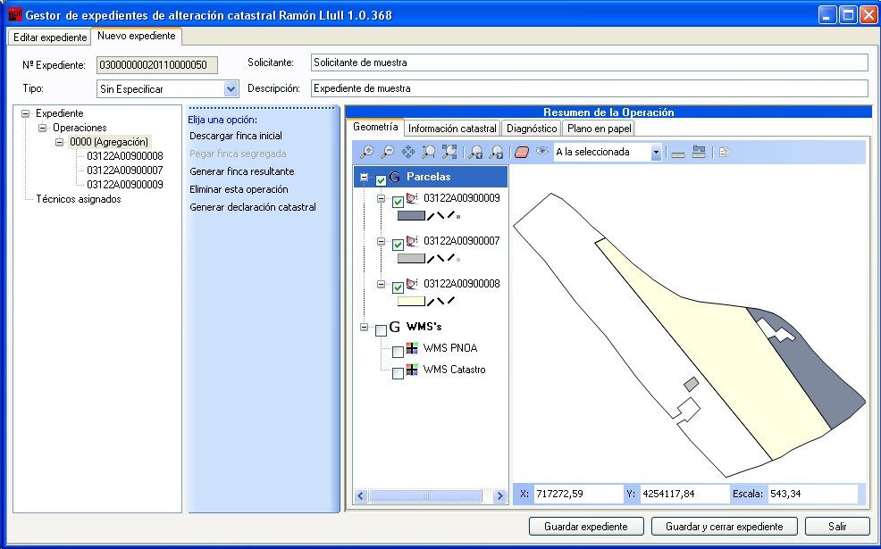

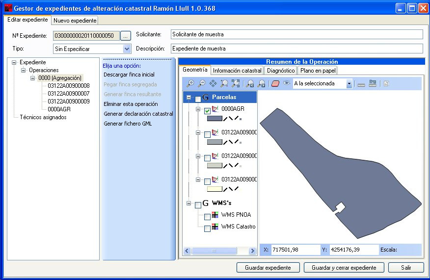

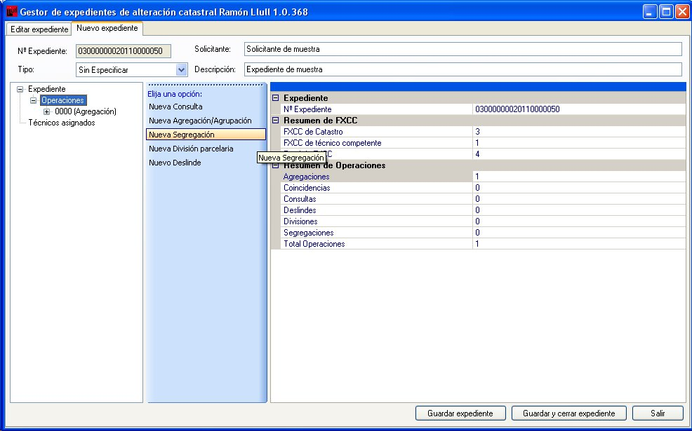

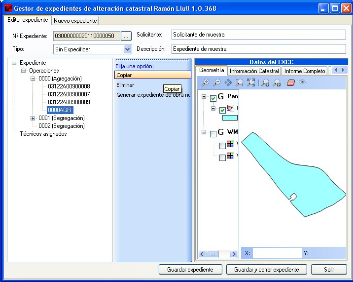

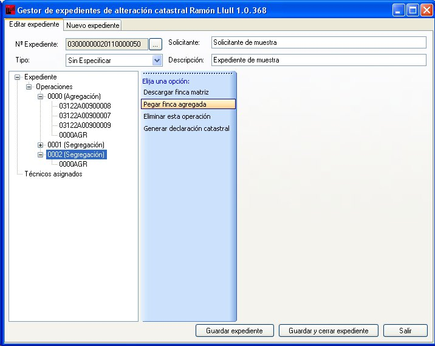

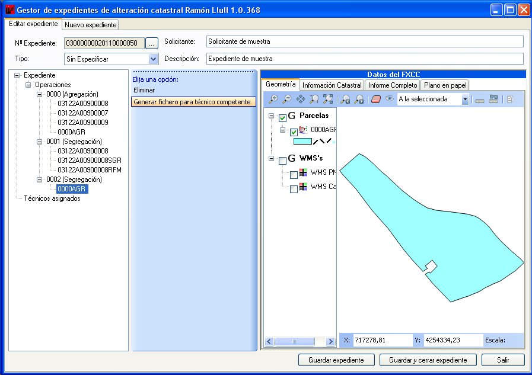

[figure not shown]

[figure not shown]

[figure not shown]

[4 more figures not shown]

Más información con instrucciones paso a paso para [Alteraciones catastrales](http://www.arsmagna.es/files/cursoBenissa/supuestos_practicos_AC.pdf)

#### Veamos un ejemplo para una edificación

[NORMA DE ENTREGA DE ACTUALIZACIONES DE LA CARTOGRAFÍA CATASTRAL RÚSTICA Y URBANA.FORMATO FXCC PARA INTERCAMBIO DE INFORMACIÓN GRÁFICA ASOCIADA A PARCELAS CATASTRALES.](http://www.catastro.minhap.gob.es/documentos/formatos_intercambio/formato_fxcc.pdf)

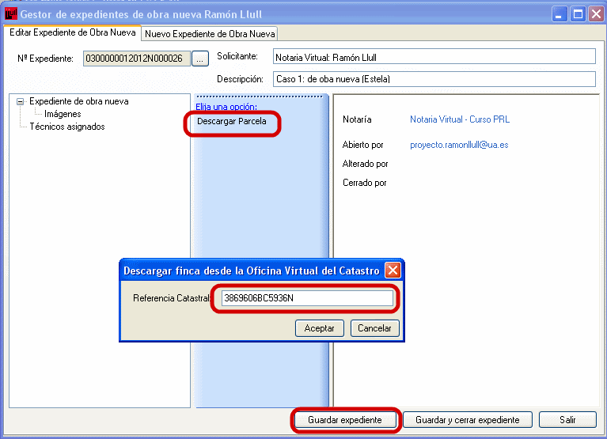

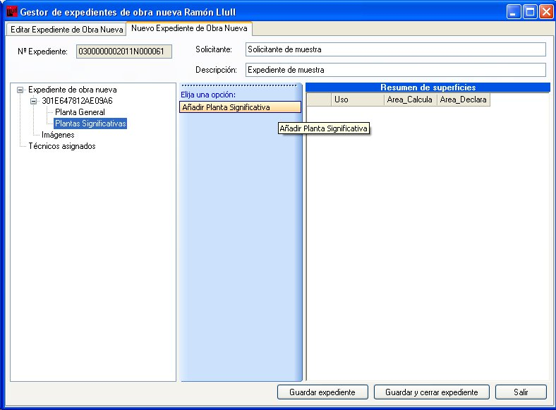

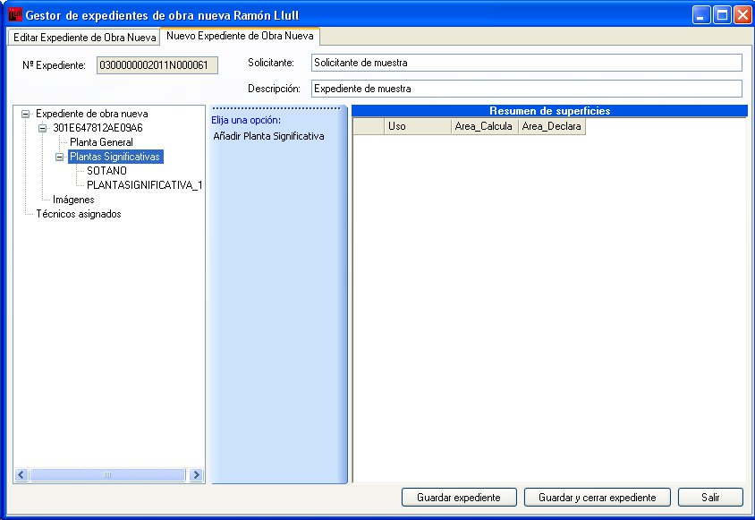

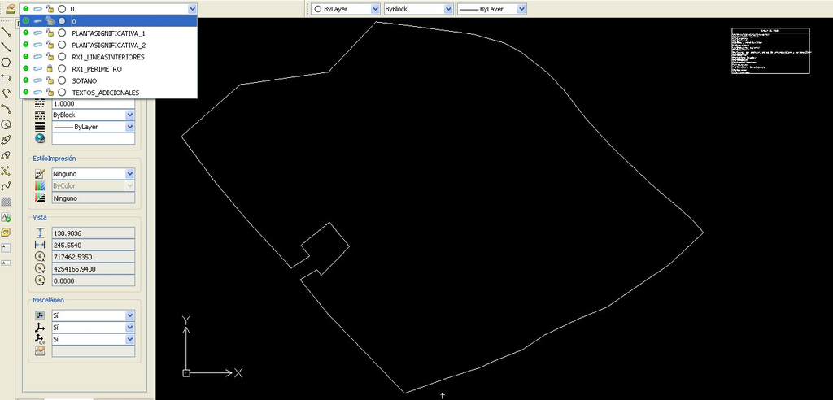

[figure not shown]

[figure not shown]

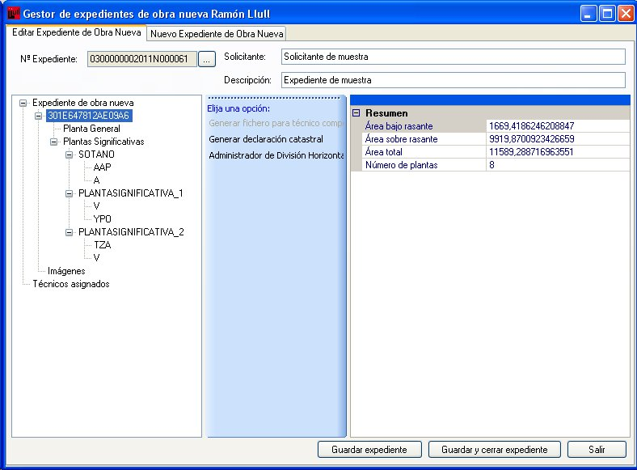

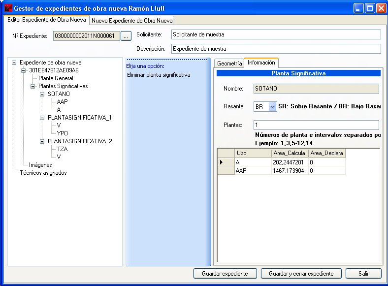

Más información con instrucciones paso a paso para [Obra Nueva y División horizontal](http://www.arsmagna.es/files/cursoBenissa/supuestos_practicos_ON.pdf)

#### ¿Cuáles son las claves funcionales del Proyecto Ramón Llull?

- Cartografía de referencia
- Coordinación de agentes
- Distribución de roles
- Seguridad en los accesos
- Almacén de datos centralizado
- Edición individualizada de expedientes
- Organización jerárquica del interfaz de usuario

## ¡Gracias! Y recordad.

#### Para consultar la documentación, descargar la aplicación y obtener información acerca de cursos y eventos visitad:

http://www.arsmagna.es #### Para solicitar ayuda técnica enviad un correo electrónico : proyecto.ramonllull@ua.es